# SOLUTIONS: Simple linear regression

FEV lung function: age then height

GRAPH Courses team

2026-06-24

# Introduction

These are instructor solutions for `fev/rsr_week_06_exercise.Rmd`. Each section shows the **question** (where applicable), **blank code** from the exercise, **completed code**, and **answer**. A consolidated **answer key** is at the end.

In this exercise you will practice **simple linear regression** on lung-function data from youths ([Kahn/Tager, JSE 2005](https://doi.org/10.1080/10691898.2005.11910559)).

- **Outcome (both models):** `fev_l`, forced expiratory volume in one second, in **litres**
- **Dataset:** `data/fev_kahn.csv`, 654 youths
- **Predictors:** `age_yrs` (years) and `height_in` (inches)

There is **no separate demo file**. **Part 1** walks through a complete example (`fev_l ~ age_yrs`) with all code filled in. **Part 2** repeats the same steps for **height**. **Part 3** compares the two models.

# PART 1: Walkthrough: FEV and age (filled in)

Read this section and **run every chunk**. The code is complete; treat this as your syntax reference for Part 2.

## Load packages and data

```r
if (!require(pacman)) install.packages("pacman")
pacman::p_load(tidyverse, here, janitor)

fev <- read_csv(here("data/fev_kahn.csv"))
glimpse(fev)
```

```
## Rows: 654
## Columns: 5
## $ age_yrs   <dbl> 9, 8, 7, 9, 9, 8, 6, 6, 8, 9, 6, 8, 8, 8, 8, 7, 5, 6, 9, 9, …
## $ fev_l     <dbl> 1.708, 1.724, 1.720, 1.558, 1.895, 2.336, 1.919, 1.415, 1.98…
## $ height_in <dbl> 57.0, 67.5, 54.5, 53.0, 57.0, 61.0, 58.0, 56.0, 58.5, 60.0, …
## $ sex       <chr> "female", "female", "female", "male", "male", "female", "fem…
## $ smoke     <chr> "non_smoker", "non_smoker", "non_smoker", "non_smoker", "non…
```

**Checkpoint:** 654 rows, 5 columns. No missing values in `fev_l` or `age_yrs`.

## Plot the relationship

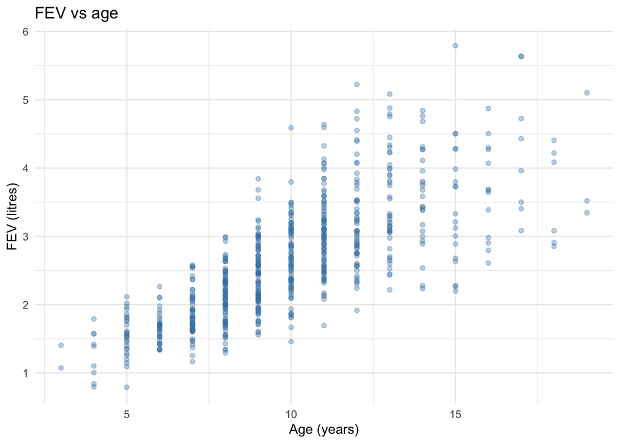

```r
ggplot(fev, aes(x = age_yrs, y = fev_l)) +
  geom_point(alpha = 0.35, color = "steelblue") +
  labs(
    title = "FEV vs age",
    x = "Age (years)",
    y = "FEV (litres)"
  ) +
  theme_minimal()
```

Older youths tend to have higher FEV. Lungs grow as children age.

## Correlation

```r
r_age <- cor(fev$fev_l, fev$age_yrs)
round(r_age, 3)
```

```
## [1] 0.756
```

**Answer:** $r \approx 0.756$, a strong **positive** linear association.

## Fit the model and read the output

```r
fev_age_model <- lm(fev_l ~ age_yrs, data = fev)
summary(fev_age_model)
```

```
##
## Call:
## lm(formula = fev_l ~ age_yrs, data = fev)
##
## Residuals:
##      Min       1Q   Median       3Q      Max
## -1.57539 -0.34567 -0.04989  0.32124  2.12786
##
## Coefficients:
##             Estimate Std. Error t value Pr(>|t|)
## (Intercept) 0.431648   0.077895   5.541 4.36e-08 ***
## age_yrs     0.222041   0.007518  29.533  < 2e-16 ***
## ---
## Signif. codes:  0 '***' 0.001 '**' 0.01 '*' 0.05 '.' 0.1 ' ' 1
##
## Residual standard error: 0.5675 on 652 degrees of freedom
## Multiple R-squared:  0.5722, Adjusted R-squared:  0.5716
## F-statistic: 872.2 on 1 and 652 DF,  p-value: < 2.2e-16
```

From the **`age_yrs` row** of the coefficients table:

| Quantity | Approximate value | Meaning |
| --- | --- | --- |
| Estimate (slope $b_1$) | 0.222 | Litres of FEV gained per extra year of age |
| `Pr(>\\|t\\|)` | $< 0.001$ | Test of $H_0: \beta_1 = 0$ |

**Answer:** Each additional year of age is associated with about **0.22 litres** higher FEV, on average.

## $R^2$

```r
summary(fev_age_model)$r.squared
```

```
## [1] 0.5722302
```

```r
r_age^2
```

```
## [1] 0.5722302
```

**Answer:** $R^2 \approx 0.572$. Age alone explains about **57%** of person-to-person variation in FEV. $0.756^2 \approx 0.572$.

## Fitted line and a prediction

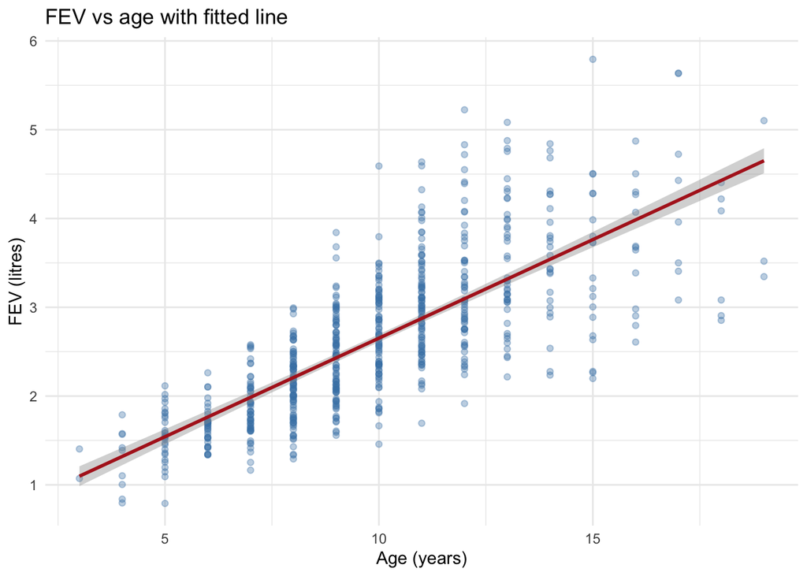

```r
ggplot(fev, aes(x = age_yrs, y = fev_l)) +
  geom_point(alpha = 0.35, color = "steelblue") +
  geom_smooth(method = "lm", se = TRUE, color = "firebrick") +
  labs(
    title = "FEV vs age with fitted line",
    x = "Age (years)",
    y = "FEV (litres)"
  ) +
  theme_minimal()
```

```r
predict(fev_age_model, newdata = data.frame(age_yrs = 10))
```

```
##        1
## 2.652058
```

**Answer:** Predicted FEV at age 10 is about **2.65 litres**.

**Before Part 2:** you should know how to go from scatter plot to `cor()`, then `lm()`, then `summary()`, then $R^2$, then `predict()`. Part 2 repeats that recipe with **height** as the predictor.

# PART 2: Your turn: FEV and height

Fill in the blanks (replace `_______`). Use Part 1 as your syntax guide.

## Scatter plot

**Question:** Does FEV tend to increase or decrease with height?

**Blank code:**

```r
ggplot(fev, aes(x = _______, y = _______)) +
  geom_point(alpha = 0.35, color = "steelblue") +
  labs(
    title = "FEV vs height",
    x = "Height (inches)",
    y = "FEV (litres)"
  ) +
  theme_minimal()
```

**Solution:**

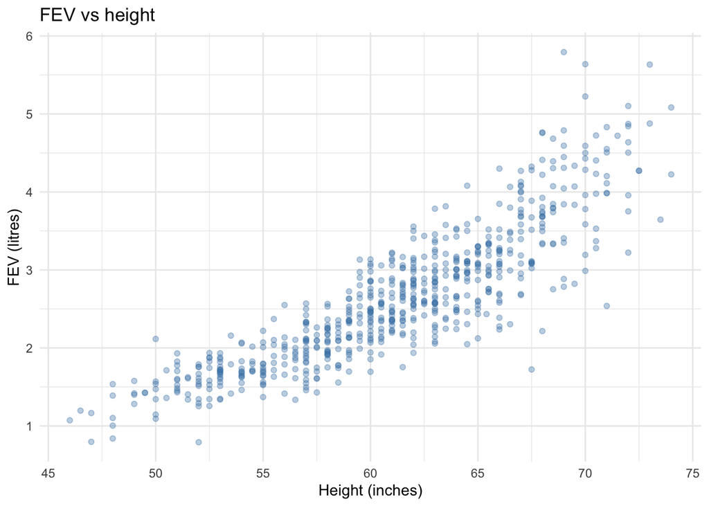

```r
ggplot(fev, aes(x = height_in, y = fev_l)) +
  geom_point(alpha = 0.35, color = "steelblue") +
  labs(
    title = "FEV vs height",
    x = "Height (inches)",
    y = "FEV (litres)"
  ) +
  theme_minimal()
```

**Answer:** FEV **increases** with height.

## Correlation

**Question:** What is $r$ for height? Is the association positive or negative?

**Blank code:**

```r
r_height <- cor(_______, _______)
round(r_height, 3)
```

**Solution:**

```r
r_height <- cor(fev$fev_l, fev$height_in)
round(r_height, 3)
```

```
## [1] 0.868
```

**Answer:** $r \approx 0.868$. The association is **positive**.

## Fit the model

**Question:** What is the slope for `height_in` (Estimate, rounded to 3 decimals)?

**Question:** Interpret the slope in plain language (include units for FEV and height).

**Question:** Is the slope statistically significant at $\alpha = 0.05$?

**Blank code:**

```r
fev_height_model <- _______(_______ ~ _______, data = fev)
summary(fev_height_model)
```

**Solution:**

```r
fev_height_model <- lm(fev_l ~ height_in, data = fev)
summary(fev_height_model)
```

```
##
## Call:
## lm(formula = fev_l ~ height_in, data = fev)
##
## Residuals:
##      Min       1Q   Median       3Q      Max
## -1.75167 -0.26619 -0.00401  0.24474  2.11936
##
## Coefficients:
##              Estimate Std. Error t value Pr(>|t|)
## (Intercept) -5.432679   0.181460  -29.94   <2e-16 ***
## height_in    0.131976   0.002955   44.66   <2e-16 ***
## ---
## Signif. codes:  0 '***' 0.001 '**' 0.01 '*' 0.05 '.' 0.1 ' ' 1
##
## Residual standard error: 0.4307 on 652 degrees of freedom
## Multiple R-squared:  0.7537, Adjusted R-squared:  0.7533
## F-statistic:  1995 on 1 and 652 DF,  p-value: < 2.2e-16
```

**Answer:** Slope $\approx 0.132$. Each additional inch of height is associated with about **0.13 litres** higher FEV, on average. **Yes**, reject $H_0$ at $\alpha = 0.05$ ($p < 0.001$).

## $R^2$

**Question:** What is $R^2$ for the height model?

**Question:** Confirm that $r^2$ from Part 2 matches $R^2$ (allowing for rounding).

**Blank code:**

```r
r_squared_height <- summary(_______)$r.squared
round(r_squared_height, 3)
```

**Solution:**

```r
r_squared_height <- summary(fev_height_model)$r.squared
round(r_squared_height, 3)
```

```
## [1] 0.754
```

**Answer:** $R^2 \approx 0.754$. Check: $0.868^2 \approx 0.754$.

## Prediction

**Question:** Predicted FEV at 60 inches (litres)?

**Blank code:**

```r
predict(
  fev_height_model,
  newdata = data.frame(_______ = 60)
)
```

**Solution:**

```r
predict(
  fev_height_model,
  newdata = data.frame(height_in = 60)
)
```

```
##        1
## 2.485855
```

**Answer:** About **2.49 litres**.

## Fitted line

**Blank code:**

```r
ggplot(fev, aes(x = height_in, y = fev_l)) +
  geom_point(alpha = 0.35, color = "steelblue") +
  geom_______(method = "lm", se = TRUE, color = "firebrick") +
  labs(
    title = "FEV vs height with fitted line",
    x = "Height (inches)",
    y = "FEV (litres)"
  ) +
  theme_minimal()
```

**Solution:**

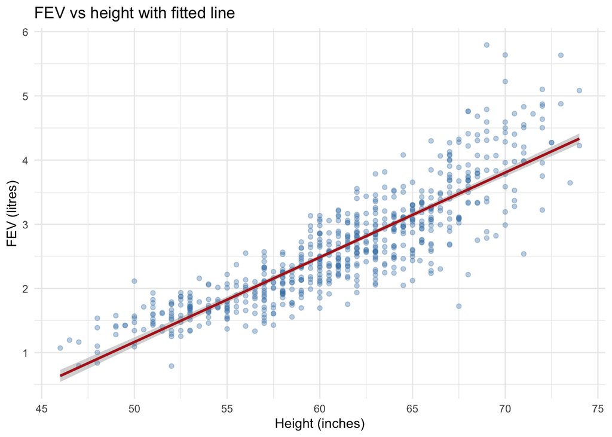

```r
ggplot(fev, aes(x = height_in, y = fev_l)) +
  geom_point(alpha = 0.35, color = "steelblue") +
  geom_smooth(method = "lm", se = TRUE, color = "firebrick") +
  labs(
    title = "FEV vs height with fitted line",
    x = "Height (inches)",
    y = "FEV (litres)"
  ) +
  theme_minimal()
```

# PART 3: Compare age and height models

Use your Part 1 walkthrough and your Part 2 answers.

Fill in the code to put both $R^2$ values side by side:

**Blank code:**

```r
tibble(
  predictor = c("age_yrs", "height_in"),
  r_squared = c(
    summary(_______)$r.squared,
    summary(_______)$r.squared
  )
) %>%
  mutate(r_squared = round(r_squared, 3))
```

**Solution:**

```r
tibble(
  predictor = c("age_yrs", "height_in"),
  r_squared = c(
    summary(fev_age_model)$r.squared,
    summary(fev_height_model)$r.squared
  )
) %>%
  mutate(r_squared = round(r_squared, 3))
```

```
## # A tibble: 2 × 2
##   predictor r_squared
##   <chr>         <dbl>
## 1 age_yrs       0.572
## 2 height_in     0.754
```

**Question:** Which predictor has the larger $|r|$, age or height?

**Answer:** **Height** ($|r| \approx 0.87$ vs $|r| \approx 0.76$ for age).

**Question:** Which model has the higher $R^2$?

**Answer:** **Height** ($R^2 \approx 0.75$ vs $R^2 \approx 0.57$ for age).

**Question:** In one or two sentences, which single predictor would you prefer for explaining FEV in this sample, and why?

**Answer:** Prefer **height**. It explains about 75% of FEV variation compared with about 57% for age alone, so predictions from the height model would be tighter.

**Question:** Age and height both increase as children grow. Why might height be a stronger predictor of FEV than age alone?

**Answer:** FEV depends on **lung size**, which tracks body size (height) more directly than age. Two youths the same age can differ in height, and the taller one typically has larger lungs and higher FEV.

# PART 4 OPTIONAL UNGRADED CHALLENGE: Smoking

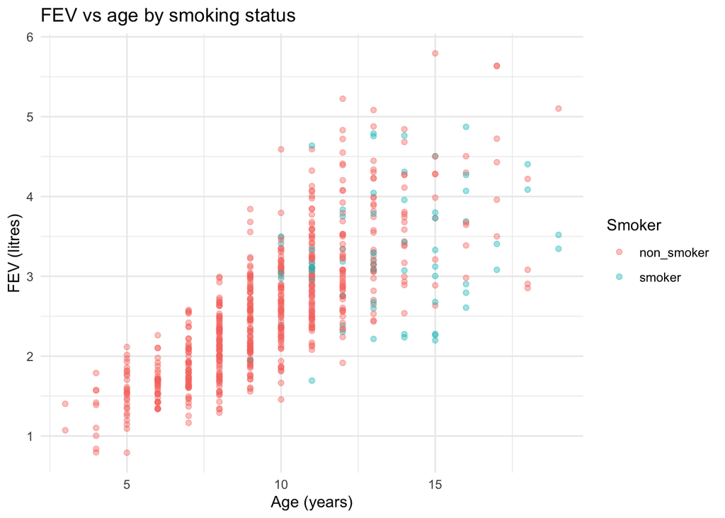

```r
ggplot(fev, aes(x = age_yrs, y = fev_l, color = factor(smoke))) +
  geom_point(alpha = 0.4) +
  labs(
    title = "FEV vs age by smoking status",
    x = "Age (years)",
    y = "FEV (litres)",
    color = "Smoker"
  ) +
  theme_minimal()
```

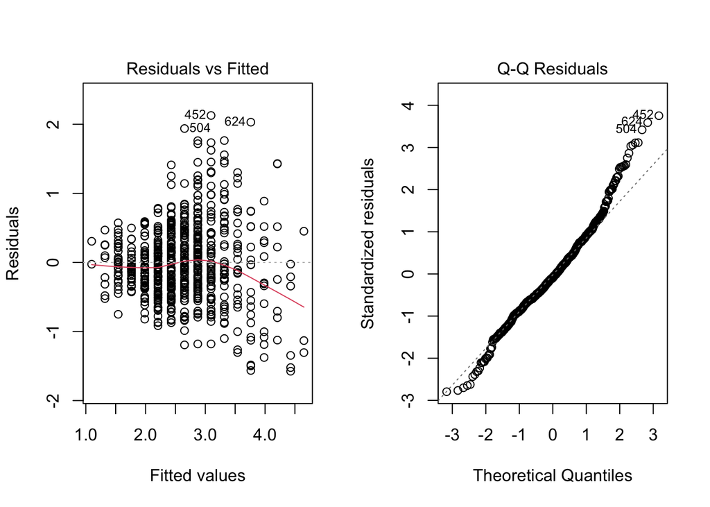

```r
par(mfrow = c(1, 2))
plot(fev_age_model, which = 1:2)
```

```r
par(mfrow = c(1, 1))
```

**Question:** After seeing the smoking plot, why might neither an age-only nor a height-only model tell the whole story about FEV?

**Answer:** **Smoking** may directly affect lung function. Smokers in this sample tend to be older, so part of the age association could be confounded. Neither single-predictor model accounts for smoking (or sex, which is also in the dataset).

# Answer key (quick reference)

| Part | Question | Answer |
| --- | --- | --- |
| 1 | $r$ (age) | ≈ 0.756 (positive) |
| 1 | Slope (age) | ≈ 0.222 L per year |
| 1 | $R^2$ (age) | ≈ 0.572 |
| 1 | Predict at age 10 | ≈ 2.65 L |
| 2 | Scatter pattern | FEV increases with height |
| 2 | $r$ (height) | ≈ 0.868 (positive) |
| 2 | Slope (height) | ≈ 0.132 L per inch; significant |
| 2 | $R^2$ (height) | ≈ 0.754 |
| 2 | Predict at 60 in | ≈ 2.49 L |
| 3 | Larger $\|r\|$ | Height |
| 3 | Higher $R^2$ | Height |
| 3 | Preferred predictor | Height (explains more variation) |
| 3 | Why height beats age | Lung size tracks height |
| 4 | Smoking | Confounding; omitted variable |

**Code blanks summary**

| Chunk | Blanks filled with |
| --- | --- |
| `scatter-height` | `height_in`, `fev_l` |
| `cor-height` | `fev$fev_l`, `fev$height_in` |
| `fit-height` | `lm`, `fev_l`, `height_in` |
| `r2-height` | `fev_height_model` |
| `predict-height` | `height_in` |
| `line-height` | `smooth` |
| `compare-r2` | `fev_age_model`, `fev_height_model` |